# Chapter 2 - Linear regression analysis

Let’s begin our analysis by opening the dataset that has been created previously. With the str()-prosedure we see that there are 7 variables of 166 observations. The data describes learning; deep is short for deep learning, stra for strategic learning and surf for surface learning.

```r
students2014 <- read.table(file= "http://s3.amazonaws.com/assets.datacamp.com/production/course_2218/datasets/learning2014.txt", header=T, sep=",")

str(students2014)
```

```
## 'data.frame':    166 obs. of  7 variables:
##  $ gender  : Factor w/ 2 levels "F","M": 1 2 1 2 2 1 2 1 2 1 ...
##  $ age     : int  53 55 49 53 49 38 50 37 37 42 ...
##  $ attitude: num  3.7 3.1 2.5 3.5 3.7 3.8 3.5 2.9 3.8 2.1 ...
##  $ deep    : num  3.58 2.92 3.5 3.5 3.67 ...
##  $ stra    : num  3.38 2.75 3.62 3.12 3.62 ...
##  $ surf    : num  2.58 3.17 2.25 2.25 2.83 ...
##  $ points  : int  25 12 24 10 22 21 21 31 24 26 ...
```

Now that we have the dataset ready, we can start analysing by making some graphs and summaries.

```r
library(GGally)
library(ggplot2)

summary(students2014)
```

```
##  gender       age           attitude          deep            stra
##  F:110   Min.   :17.00   Min.   :1.400   Min.   :1.583   Min.   :1.250
##  M: 56   1st Qu.:21.00   1st Qu.:2.600   1st Qu.:3.333   1st Qu.:2.625
##          Median :22.00   Median :3.200   Median :3.667   Median :3.188
##          Mean   :25.51   Mean   :3.143   Mean   :3.680   Mean   :3.121
##          3rd Qu.:27.00   3rd Qu.:3.700   3rd Qu.:4.083   3rd Qu.:3.625
##          Max.   :55.00   Max.   :5.000   Max.   :4.917   Max.   :5.000
##       surf           points
##  Min.   :1.583   Min.   : 7.00
##  1st Qu.:2.417   1st Qu.:19.00
##  Median :2.833   Median :23.00
##  Mean   :2.787   Mean   :22.72
##  3rd Qu.:3.167   3rd Qu.:27.75
##  Max.   :4.333   Max.   :33.00
```

By using the function summary() we see important statistics of the variables in the data. Only “gender” is a dichotomous variable at the dataset, and all the other variables are continous. However, there are clear minimum and maximum points for each of the 7 variables. The relation between variables can easily be seen in the graph box of all the variables in the model.

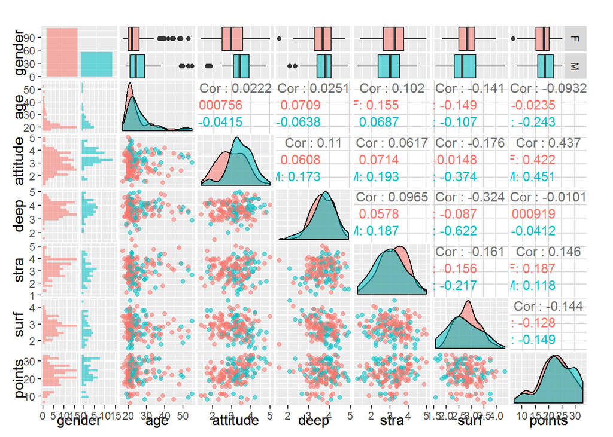

```r
p <- ggpairs(students2014, mapping = aes(col=gender, alpha=0.3), lower = list(combo = wrap("facethist", bins = 20)))

p
```

Let’s fit a regression model with variables “attitude” “stra” and “surf” as explanatory variables for target variable exam points, “points”. These explanatory variables have the greatest correlation with “points” and that is why they might form a valid regression model.

```r
the_model <- lm(points ~ attitude + stra + surf, data=students2014 )

summary(the_model)
```

```
##
## Call:
## lm(formula = points ~ attitude + stra + surf, data = students2014)
##
## Residuals:
##      Min       1Q   Median       3Q      Max
## -17.1550  -3.4346   0.5156   3.6401  10.8952
##
## Coefficients:
##             Estimate Std. Error t value Pr(>|t|)
## (Intercept)  11.0171     3.6837   2.991  0.00322 **
## attitude      3.3952     0.5741   5.913 1.93e-08 ***
## stra          0.8531     0.5416   1.575  0.11716
## surf         -0.5861     0.8014  -0.731  0.46563
## ---
## Signif. codes:  0 '***' 0.001 '**' 0.01 '*' 0.05 '.' 0.1 ' ' 1
##
## Residual standard error: 5.296 on 162 degrees of freedom
## Multiple R-squared:  0.2074, Adjusted R-squared:  0.1927
## F-statistic: 14.13 on 3 and 162 DF,  p-value: 3.156e-08
```

At the test statistic’s coefficients part we see that only “attitude” has a significant-enough p-value (the last column). In general, we now have a regression model Y= 11.01 + 3.40 x attitude + 0.85 x stra - 0.59 x surf.

So let’s fit the model again with only the significant variable in p-value sense.

```r
the_model <- lm(points ~ attitude, data=students2014 )

coef(the_model)
```

```
## (Intercept)    attitude
##    11.63715     3.52546
```

When counting coefficents of the new model, we get that the slope b_1=3.52546. It means that when there is a one-unit change in the explanatory variable X, that is “attitude”, points increase by about 3.5 units.

The multiple R-squared tells us the R^2 value =0.21. This is rather small, because it tells, that the explanatory variables only explain about 21% of the variance of the result variable, which is exam points. Adjusted R-squared value tells also about the poor explanation volume; when the number of explanatory variables is included at the review, only around 19% of Y’s variance is explained.

Finally we can interpret the model results with some regression diagnostics plots.

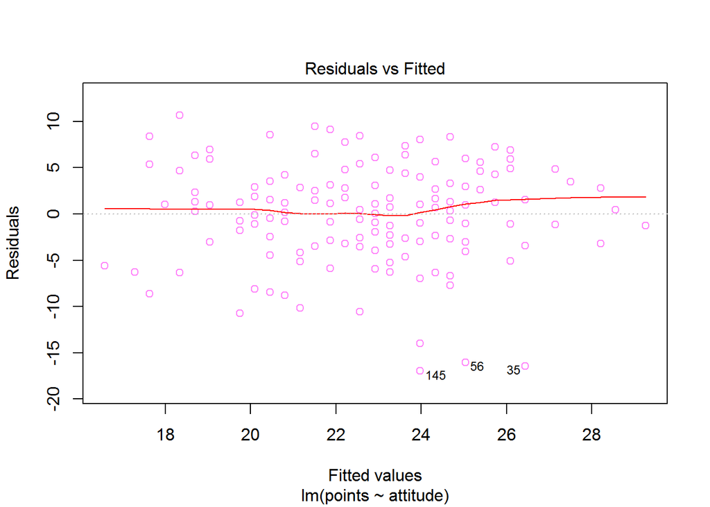

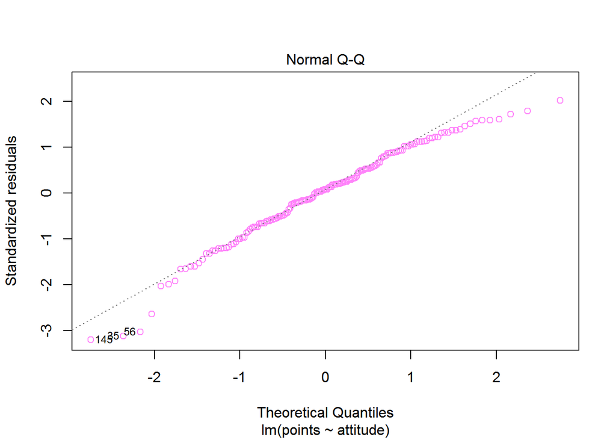

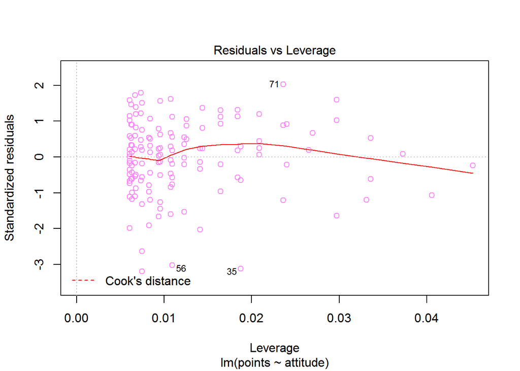

```r
plot(the_model, which=c(1, 2, 5), col="orchid1")
```

“Residuals vs fitted values”-plot shows if the residuals in the model have any non-linear patterns. Luckily there are only a few outliers, observations 145, 56, and 35, that could be removed. We can say that our linear model is a good option for these variables.

With the “Normal Q-Q plot” we can interpret the normality of the residuals, that is the error term. With this model the observations follow quite kindly the line that is drawn in the graph. We can say that normality is approximately true.

“Residuals vs leverage”-plot tells us about “influential cases”, which means it tells whether there are some observations that influence estimates too much and thus will have an effect on the regression line.